# analysis code

Grace Manninen

2025-03-24

loading in packages/libraries

```r
library(dplyr)
```

```r
library(stringr)
library(jsonlite)
library(ggplot2)
```

loading in data

```r
#LOAD IN DATA
# Block 1 data: data 1: This data looks at charismatic - likert - scary - likert
# Block 2 data: data 2: This data looks at fixation cross - scary - likert

data1 <- read.csv("graces_simulateddata_analysis.csv")
data2 <- read.csv("fixation-scary.csv")

#setting seed
set.seed(20)
```

data 1

```r
#inspect the data
class(data1)
```

```
## [1] "data.frame"
```

```r
#"data.frame"

#getting image rows and extacting file names
image_rows1 <- grep("<img src=", data1$stimulus)
print(image_rows1)
```

```
##  [1]  5  7  9 11 13 15 17 19 21 23 25 27 29 31 33 35
```

```r
#5  7  9 11 13 15 17 19 21 23 25 27 29 31 33 35

image_filenames1 <- gsub('.*<img src=\\"|\\\".*', '', data1$stimulus[image_rows1])
print(image_filenames1)
```

```
##  [1] "charismatic/wolf.jpg"        "scary/wasp.jpg"
##  [3] "charismatic/zebra.jpg"       "scary/snake.jpg"
##  [5] "charismatic/elephant.jpg"    "scary/cockroach.jpg"
##  [7] "charismatic/cheetah.jpeg"    "scary/bull.jpg"
##  [9] "charismatic/lion.jpg"        "scary/roundworm.png"
## [11] "charismatic/giant_panda.jpg" "scary/maggot.jpg"
## [13] "charismatic/gorilla.jpg"     "scary/tapeworm.jpg"
## [15] "charismatic/tiger.jpg"       "scary/spider.jpg"
```

```r
# [1] "charismatic/wolf.jpg"        "scary/wasp.jpg"
# [3] "charismatic/zebra.jpg"       "scary/snake.jpg"
# [5] "charismatic/elephant.jpg"    "scary/cockroach.jpg"
# [7] "charismatic/cheetah.jpeg"    "scary/bull.jpg"
# [9] "charismatic/lion.jpg"        "scary/roundworm.png"
# [11] "charismatic/giant_panda.jpg" "scary/maggot.jpg"
# [13] "charismatic/gorilla.jpg"     "scary/tapeworm.jpg"
# [15] "charismatic/tiger.jpg"       "scary/spider.jpg"

#because likert responses follow image file... to identify likert responses

likert_rows1 <- image_rows1 + 1
print(likert_rows1)
```

```
##  [1]  6  8 10 12 14 16 18 20 22 24 26 28 30 32 34 36
```

```r
#6  8 10 12 14 16 18 20 22 24 26 28 30 32 34 36

funny <- str_extract(data1$response[likert_rows1], '"funny":([0-5])') %>%
  str_remove('"funny":') %>% as.integer()

motherly <- str_extract(data1$response[likert_rows1], '"motherly":([0-5])') %>%
  str_remove('"motherly":') %>% as.integer()

friendly <- str_extract(data1$response[likert_rows1], '"friendly":([0-5])') %>%
  str_remove('"friendly":') %>% as.integer()

cute <- str_extract(data1$response[likert_rows1], '"cute":([0-5])') %>%
  str_remove('"cute":') %>% as.integer()

protective <- str_extract(data1$response[likert_rows1], '"protective":([0-5])') %>%
  str_remove('"protective":') %>% as.integer()

help <- str_extract(data1$response[likert_rows1], '"help":([0-5])') %>%
  str_remove('"help":') %>% as.integer()

image_likert_df <- data.frame(
  Image = image_filenames1,
  Funny = funny,
  Motherly = motherly,
  Friendly = friendly,
  Cute = cute,
  Protective = protective,
  Help = help
)

print(image_likert_df)
```

```
##                          Image Funny Motherly Friendly Cute Protective Help
## 1         charismatic/wolf.jpg     4        4        4    4          4    4
## 2               scary/wasp.jpg     0        0        0    0          0    0
## 3        charismatic/zebra.jpg     4        4        4    4          4    4
## 4              scary/snake.jpg     0        0        0    0          0    0
## 5     charismatic/elephant.jpg     4        4        4    4          4    4
## 6          scary/cockroach.jpg     0        0        0    0          0    0
## 7     charismatic/cheetah.jpeg     4        4        4    4          4    4
## 8               scary/bull.jpg    NA       NA       NA   NA         NA   NA
## 9         charismatic/lion.jpg     4        4        4    4          4    4
## 10         scary/roundworm.png    NA       NA       NA   NA         NA   NA
## 11 charismatic/giant_panda.jpg     4        4        4    4          4    4
## 12            scary/maggot.jpg    NA       NA       NA   NA         NA   NA
## 13     charismatic/gorilla.jpg     4        4        4    4          4    4
## 14          scary/tapeworm.jpg    NA       NA       NA   NA         NA   NA
## 15       charismatic/tiger.jpg     4        4        4    4          4    4
## 16            scary/spider.jpg    NA       NA       NA   NA         NA   NA
```

```r
scary_images <- image_likert_df[grepl("scary", image_likert_df$Image), ]
print(scary_images)
```

```
##                  Image Funny Motherly Friendly Cute Protective Help
## 2       scary/wasp.jpg     0        0        0    0          0    0
## 4      scary/snake.jpg     0        0        0    0          0    0
## 6  scary/cockroach.jpg     0        0        0    0          0    0
## 8       scary/bull.jpg    NA       NA       NA   NA         NA   NA
## 10 scary/roundworm.png    NA       NA       NA   NA         NA   NA
## 12    scary/maggot.jpg    NA       NA       NA   NA         NA   NA
## 14  scary/tapeworm.jpg    NA       NA       NA   NA         NA   NA
## 16    scary/spider.jpg    NA       NA       NA   NA         NA   NA
```

```r
#now scary_images displays a table that shows the scary animals with their corresponding likert scale responses
```

data 2

```r
#view data
head(data2)
```

```
##   success timeout failed_images failed_audio failed_video
## 1    TRUE   FALSE            []           []           []
## 2      NA      NA
## 3      NA      NA
## 4      NA      NA
## 5      NA      NA
## 6      NA      NA
##               trial_type trial_index time_elapsed internal_node_id   rt
## 1                preload           0          576          0.0-0.0
## 2 html-keyboard-response           1         1100          0.0-1.0  523
## 3 html-keyboard-response           2         2057          0.0-2.0  957
## 4   html-button-response           3         3972          0.0-3.0 1913
## 5 html-keyboard-response           4         4975          0.0-4.0 null
## 6   html-button-response           5         7738          0.0-5.0 2762
##                                                                                                                                                                                                                                                                                                          …
## 1
## 2                                                                                                                                                                                                                                                                                                        …
## 3 \n    <p> Welcome to the experiment!</p>\n          \n    <p>If you have any animal phobias, please do not continue. \n    Make sure to look after your mental well-being. \n          If at any point in the experiment you don't feel well, please feel free to exit the experiment.\n          There…
## 4                                                                                                                                                                                                                                                                                            <p> For this…
## 5                                                                                                                                                                                                                                                                                                        …
## 6                                                                                                                                                                                                                                                                                                        …
##   response question_order
## 1
## 2
## 3
## 4        0
## 5     null
## 6        0
```

```r
colnames(data2)
```

```
##  [1] "success"          "timeout"          "failed_images"    "failed_audio"
##  [5] "failed_video"     "trial_type"       "trial_index"      "time_elapsed"
##  [9] "internal_node_id" "rt"               "stimulus"         "response"
## [13] "question_order"
```

```r
#clean data, take out fixation cross data
stimulus_rows <- grep("<div style=\"font-size:60px;\">\\+<\\/div>", data2$stimulus)
data_clean2 <- data2[-stimulus_rows, ]
head(data_clean2)
```

```
##   success timeout failed_images failed_audio failed_video
## 1    TRUE   FALSE            []           []           []
## 2      NA      NA
## 3      NA      NA
## 4      NA      NA
## 6      NA      NA
## 7      NA      NA
##               trial_type trial_index time_elapsed internal_node_id   rt
## 1                preload           0          576          0.0-0.0
## 2 html-keyboard-response           1         1100          0.0-1.0  523
## 3 html-keyboard-response           2         2057          0.0-2.0  957
## 4   html-button-response           3         3972          0.0-3.0 1913
## 6   html-button-response           5         7738          0.0-5.0 2762
## 7          survey-likert           6        16354          0.0-6.0 8611
##                                                                                                                                                                                                                                                                                                          …
## 1
## 2                                                                                                                                                                                                                                                                                                        …
## 3 \n    <p> Welcome to the experiment!</p>\n          \n    <p>If you have any animal phobias, please do not continue. \n    Make sure to look after your mental well-being. \n          If at any point in the experiment you don't feel well, please feel free to exit the experiment.\n          There…
## 4                                                                                                                                                                                                                                                                                            <p> For this…
## 6                                                                                                                                                                                                                                                                                                        …
## 7
##                                                                 response
## 1
## 2
## 3
## 4                                                                      0
## 6                                                                      0
## 7 {"funny":1,"motherly":1,"friendly":1,"cute":1,"protective":1,"help":1}
##   question_order
## 1
## 2
## 3
## 4
## 6
## 7  [0,1,2,3,4,5]
```

```r
#extracting file names
image_rows2 <- grep("<img src=", data_clean2$stimulus)
image_filenames2 <- gsub('.*<img src=\\"|\\\".*', '', data_clean2$stimulus[image_rows2])
print(image_filenames2)
```

```
## [1] "scary/roundworm.png" "scary/tapeworm.jpg"  "scary/maggot.jpg"
## [4] "scary/cockroach.jpg" "scary/spider.jpg"    "scary/snake.jpg"
## [7] "scary/wasp.jpg"      "scary/bull.jpg"
```

```r
#because likert responses follow image file... to identify likert responses

likert_rows2 <- image_rows2 + 1
print(likert_rows2)
```

```
## [1]  6  8 10 12 14 16 18 20
```

```r
head(data_clean2$response[likert_rows2])
```

```
## [1] "{\"funny\":1,\"motherly\":1,\"friendly\":1,\"cute\":1,\"protective\":1,\"help\":1}"
## [2] "{\"funny\":0,\"motherly\":0,\"friendly\":0,\"cute\":0,\"protective\":0,\"help\":0}"
## [3] "{\"funny\":3,\"motherly\":2,\"friendly\":1,\"cute\":2,\"protective\":2,\"help\":0}"
## [4] "{\"funny\":3,\"motherly\":3,\"friendly\":2,\"cute\":2,\"protective\":2,\"help\":1}"
## [5] "{\"funny\":1,\"motherly\":1,\"friendly\":1,\"cute\":1,\"protective\":\"\",\"help\":1}"
## [6] "{\"funny\":1,\"motherly\":3,\"friendly\":0,\"cute\":2,\"protective\":4,\"help\":2}"
```

```r
likert_responses2 <- lapply(data_clean2$response[likert_rows2], fromJSON)
##going to check some rows of likert response corresponding to the image

print(likert_responses2[[1]]) #roundworm - matches
```

```
## $funny
## [1] 1
##
## $motherly
## [1] 1
##
## $friendly
## [1] 1
##
## $cute
## [1] 1
##
## $protective
## [1] 1
##
## $help
## [1] 1
```

```r
print(likert_responses2[[2]]) #tapeworm - matches
```

```
## $funny
## [1] 0
##
## $motherly
## [1] 0
##
## $friendly
## [1] 0
##
## $cute
## [1] 0
##
## $protective
## [1] 0
##
## $help
## [1] 0
```

```r
print(likert_responses2[[3]]) #maggot - matches
```

```
## $funny
## [1] 3
##
## $motherly
## [1] 2
##
## $friendly
## [1] 1
##
## $cute
## [1] 2
##
## $protective
## [1] 2
##
## $help
## [1] 0
```

```r
#... looks good

data_combined2 <- data.frame(
  Image = image_filenames2,
  Funny = sapply(likert_responses2, function(x) x$funny),
  Motherly = sapply(likert_responses2, function(x) x$motherly),
  Friendly = sapply(likert_responses2, function(x) x$friendly),
  Cute = sapply(likert_responses2, function(x) x$cute),
  Protective = sapply(likert_responses2, function(x) x$protective),
  Help = sapply(likert_responses2, function(x) x$help),
  stringsAsFactors = FALSE
)
```

now the data is sorted and cleaned check once more before analysis

```r
#data1
data1table <- scary_images
print(data1table)
```

```
##                  Image Funny Motherly Friendly Cute Protective Help
## 2       scary/wasp.jpg     0        0        0    0          0    0
## 4      scary/snake.jpg     0        0        0    0          0    0
## 6  scary/cockroach.jpg     0        0        0    0          0    0
## 8       scary/bull.jpg    NA       NA       NA   NA         NA   NA
## 10 scary/roundworm.png    NA       NA       NA   NA         NA   NA
## 12    scary/maggot.jpg    NA       NA       NA   NA         NA   NA
## 14  scary/tapeworm.jpg    NA       NA       NA   NA         NA   NA
## 16    scary/spider.jpg    NA       NA       NA   NA         NA   NA
```

```r
#data2
data2table <- data_combined2
print(data2table)
```

```
##                 Image Funny Motherly Friendly Cute Protective Help
## 1 scary/roundworm.png     1        1        1    1          1    1
## 2  scary/tapeworm.jpg     0        0        0    0          0    0
## 3    scary/maggot.jpg     3        2        1    2          2    0
## 4 scary/cockroach.jpg     3        3        2    2          2    1
## 5    scary/spider.jpg     1        1        1    1               1
## 6     scary/snake.jpg     1        3        0    2          4    2
## 7      scary/wasp.jpg     1        2        0    1          2    2
## 8      scary/bull.jpg     2        3        0    2          3    2
```

I have clean and organized table’s of data that has the information I want to compare block 1 and block 2

To run the Mann-Whitney U test, participants data that has N/A values or unanswered questions will be discarded. Also partcipants data that has the same answer put in a row will be discarded. Enough sets of **complete (from the above criteria) data for each block (n=44) will need to be collected.

Each data set, will go through the above (respective if they are block 1 or block 2), to get rid of unnecessary data collected, to prepare for the inferential tests.

To prepare for the Mann-Whitney U test

HYPOTHESIS: H0 (null hypothesis): Block 1 and Block 2 will not have a significant difference, failing to reject the null hypothesis H1 (alternative hypothesis): Block 1 and Block 2 will be significantly different, rejecting the null hypothesis

creating a new data frame - to simplify it: it will include simulated data where there is going to be an assumed effect of serial dependence. There will be no missing data (no N/A).

```r
datafinal <- data.frame(
  participantID = 1:88,
  condition = rep(c("Block1", "Block2"), each=44),
  funny = rep(0, each=88),
  cute = rep(0, each=88),
  friendly = rep(0, each = 88),
  help = rep(0, each=88),
  motherly = rep(0, each=88),
  protective = rep(0, each=88),
  overall=rep(0, each=88)
)
```

[reminder that this simulated data for block 1 and block 2 is participants average for what they scored for each likert scale question, for all of the stimuli (scary images)]

block 1 -> should have a range of 1:5 for the responses, since assuming an effect of serial dependence, charismatic stimuli will cause scary stimuli to be more liked

block 2 -> should have a smaller and lower range, 1:4, for the responses, since assuming there will not be an effect of serial dependence, since fixation cross stimuli (control) is being shown instead of charismatic animal stimuli

FUNNY -> making simulated data to show my expected effect of serial dependence

```r
#SIMULATE FUNNY DATA
datafinal$funny[datafinal$condition=="Block1"] <- sample(1:5, 44, replace=TRUE)

#assuming bc of block 2, nnot seeing charismatic -> should have a lower average score (no serial dependence), only 1:4

datafinal$funny[datafinal$condition=="Block2"] <- sample(1:4, 44, replace=TRUE)
```

CUTE -> making simulated data to show my expected effect of serial dependence

```r
#SIMULATE FUNNY DATA
datafinal$cute[datafinal$condition=="Block1"] <- sample(1:5, 44, replace=TRUE)

#assuming bc of block 2, not seeing charismatic -> should have a lower average score (no serial dependence), only 1:4

datafinal$cute[datafinal$condition=="Block2"] <- sample(1:4, 44, replace=TRUE)
```

FRIENDLY -> making simulated data to show my expected effect of serial dependence

```r
#SIMULATE FUNNY DATA
datafinal$friendly[datafinal$condition=="Block1"] <- sample(1:5, 44, replace=TRUE)

#assuming bc of block 2, nnot seeing charismatic -> should have a lower average score (no serial dependence), only 1:4

datafinal$friendly[datafinal$condition=="Block2"] <- sample(1:4, 44, replace=TRUE)
```

HELP -> making simulated data to show my expected effect of serial dependence

```r
#SIMULATE FUNNY DATA
datafinal$help[datafinal$condition=="Block1"] <- sample(1:5, 44, replace=TRUE)

#assuming bc of block 2, nnot seeing charismatic -> should have a lower average score (no serial dependence), only 1:4

datafinal$help[datafinal$condition=="Block2"] <- sample(1:4, 44, replace=TRUE)
```

MOTHERLY -> making simulated data to show my expected effect of serial dependence

```r
#SIMULATE FUNNY DATA
datafinal$motherly[datafinal$condition=="Block1"] <- sample(1:5, 44, replace=TRUE)

#assuming bc of block 2, nnot seeing charismatic -> should have a lower average score (no serial dependence), only 1:4

datafinal$motherly[datafinal$condition=="Block2"] <- sample(1:4, 44, replace=TRUE)
```

PROTECTIVE -> making simulated data to show my expected effect of serial dependence

```r
#SIMULATE FUNNY DATA
datafinal$protective[datafinal$condition=="Block1"] <- sample(1:5, 44, replace=TRUE)

#assuming bc of block 2, nnot seeing charismatic -> should have a lower average score (no serial dependence), only 1:4

datafinal$protective[datafinal$condition=="Block2"] <- sample(1:4, 44, replace=TRUE)
```

overall scores for each participant

```r
datafinal$overall <- rowMeans(datafinal[,3:9])
```

Planned Analysis: Mann-Whitney U test for overall … now I have a table (datafinal) with simulated data, that should show me that block 1 will have higher scores (likert scale question (6), all on a scale of (1-5)), as higher scores mean in general that the animal is in general rated higher (cuter, friendlier, etc).

```r
overall1 <- datafinal$overall[datafinal$condition=="Block1"]
overall2 <- datafinal$overall[datafinal$condition=="Block2"]
```

Check what the average is for block 1 vs block 2

```r
mean(overall1) #3.022727
```

```
## [1] 2.753247
```

```r
mean(overall2) #2.386364
```

```
## [1] 2.237013
```

the results are what I would have expected, it makes sense that the overall score for block 1 is higher then block 2

but I want to test if this is a significant effect, so I will do a Mann-Whitey U test (Wilcoxon rank-sum test)

OVERALL

```r
wilcox.test(overall1, overall2)
```

```
##
##  Wilcoxon rank sum test with continuity correction
##
## data:  overall1 and overall2
## W = 1533.5, p-value = 2.183e-06
## alternative hypothesis: true location shift is not equal to 0
```

The difference between the overall scores show significant effects (W = 1533.5, p-value = 2.183e-06 )

can check other effects too…

FUNNY

```r
funny1 <- datafinal$funny[datafinal$condition=="Block1"]
funny2 <- datafinal$funny[datafinal$condition=="Block2"]

wilcox.test(funny1, funny2)
```

```
##
##  Wilcoxon rank sum test with continuity correction
##
## data:  funny1 and funny2
## W = 1078.5, p-value = 0.3481
## alternative hypothesis: true location shift is not equal to 0
```

The difference between the funny scores show non-significant effects (W = 1078.5, p-value = 0.3481 )

CUTE

```r
cute1 <- datafinal$cute[datafinal$condition=="Block1"]
cute2 <- datafinal$cute[datafinal$condition=="Block2"]

wilcox.test(cute1, cute2)
```

```
##
##  Wilcoxon rank sum test with continuity correction
##
## data:  cute1 and cute2
## W = 1181, p-value = 0.06959
## alternative hypothesis: true location shift is not equal to 0
```

The difference between the cute scores show non-significant effects (W = 1181, p-value = 0.06959 )

FRIENDLY

```r
friendly1 <- datafinal$friendly[datafinal$condition=="Block1"]
friendly2 <- datafinal$friendly[datafinal$condition=="Block2"]

wilcox.test(friendly1, friendly2)
```

```
##
##  Wilcoxon rank sum test with continuity correction
##
## data:  friendly1 and friendly2
## W = 1243.5, p-value = 0.01899
## alternative hypothesis: true location shift is not equal to 0
```

The difference between the friendly scores show significant effects (W = 1243.5, p-value = 0.01899 )

HELP

```r
help1 <- datafinal$help[datafinal$condition=="Block1"]
help2 <- datafinal$help[datafinal$condition=="Block2"]

wilcox.test(help1, help2)
```

```
##
##  Wilcoxon rank sum test with continuity correction
##
## data:  help1 and help2
## W = 1288.5, p-value = 0.006259
## alternative hypothesis: true location shift is not equal to 0
```

The difference between the help scores show significant effects (W = 1288.5, p-value = 0.006259 )

MOTHERLY

```r
motherly1 <- datafinal$motherly[datafinal$condition=="Block1"]
motherly2 <- datafinal$motherly[datafinal$condition=="Block2"]

wilcox.test(motherly1, motherly2)
```

```
##
##  Wilcoxon rank sum test with continuity correction
##
## data:  motherly1 and motherly2
## W = 1277.5, p-value = 0.008229
## alternative hypothesis: true location shift is not equal to 0
```

PROTECTIVE

```r
protective1 <- datafinal$protective[datafinal$condition=="Block1"]
protective2 <- datafinal$protective[datafinal$condition=="Block2"]

wilcox.test(protective1, protective2)
```

```
##
##  Wilcoxon rank sum test with continuity correction
##
## data:  protective1 and protective2
## W = 1189.5, p-value = 0.05834
## alternative hypothesis: true location shift is not equal to 0
```

data visualization - for block 1 vs block 2 - making bar graphs for each likert scale question means to compare block 1 and block 2 - error bars is standard error (upper bound and lower bound)

OVERALL

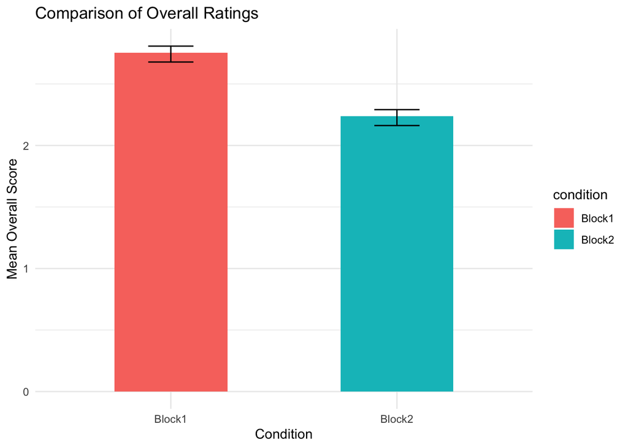

```r
overall_means <- data.frame(
  condition = c("Block1", "Block2"),
  mean_overall = c(mean(overall1), mean(overall2))
)

ggplot(overall_means, aes(x = condition, y = mean_overall, fill = condition)) +
  geom_bar(stat = "identity", width = 0.5) +
  geom_errorbar(aes(ymin = mean_overall - sd(overall1)/sqrt(length(overall1)),
                    ymax = mean_overall + sd(overall2)/sqrt(length(overall2))), width = 0.2) +
  theme_minimal() +
  labs(title = "Comparison of Overall Ratings", x = "Condition", y = "Mean Overall Score")
```

FUNNY

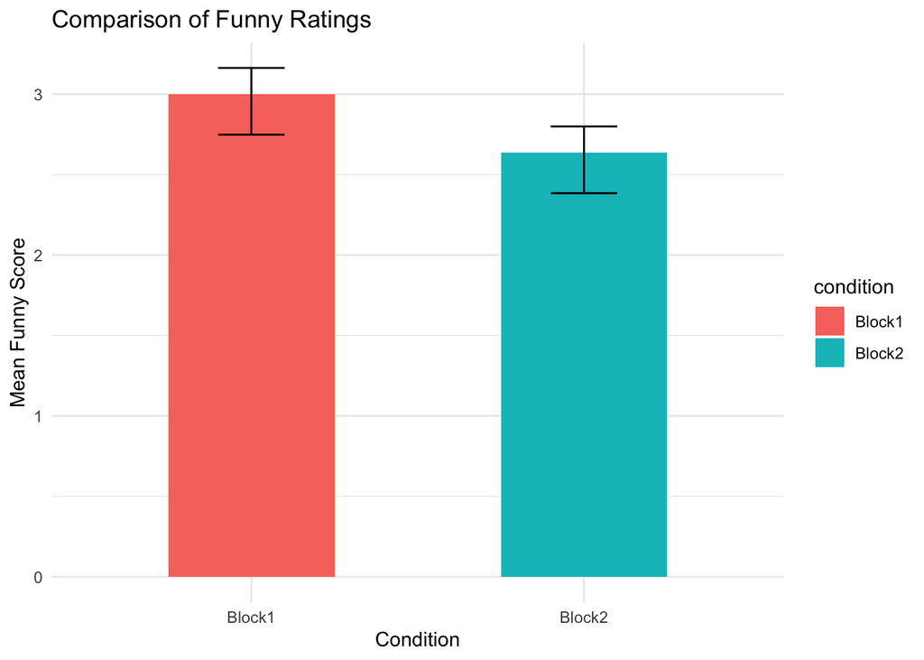

```r
funny_means <- data.frame(
  condition = c("Block1", "Block2"),
  mean_funny = c(mean(funny1), mean(funny2))
)

ggplot(funny_means, aes(x = condition, y = mean_funny, fill = condition)) +
  geom_bar(stat = "identity", width = 0.5) +
  geom_errorbar(aes(ymin = mean_funny - sd(funny1)/sqrt(length(funny1)),
                    ymax = mean_funny + sd(funny2)/sqrt(length(funny2))), width = 0.2) +
  theme_minimal() +
  labs(title = "Comparison of Funny Ratings", x = "Condition", y = "Mean Funny Score")
```

CUTE

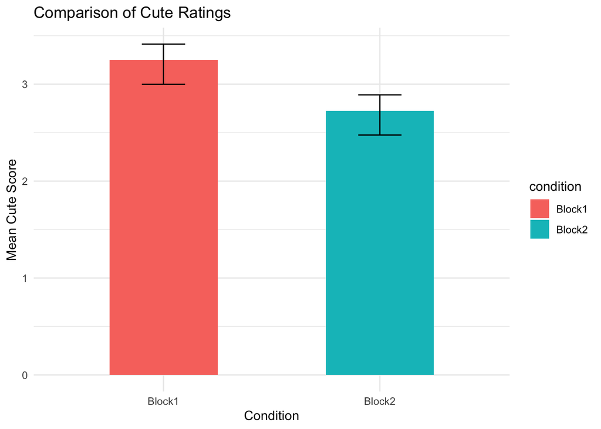

```r
cute_means <- data.frame(
  condition = c("Block1", "Block2"),
  mean_cute = c(mean(cute1), mean(cute2))
)

ggplot(cute_means, aes(x = condition, y = mean_cute, fill = condition)) +
  geom_bar(stat = "identity", width = 0.5) +
  geom_errorbar(aes(ymin = mean_cute - sd(funny1)/sqrt(length(funny1)),
                    ymax = mean_cute + sd(funny2)/sqrt(length(funny2))), width = 0.2) +
  theme_minimal() +
  labs(title = "Comparison of Cute Ratings", x = "Condition", y = "Mean Cute Score")
```

FRIENDLY

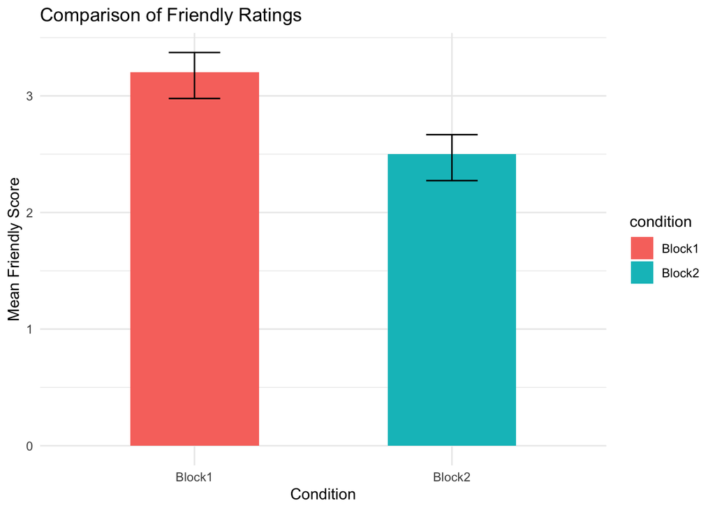

```r
friendly_means <- data.frame(
  condition = c("Block1", "Block2"),
  mean_friendly = c(mean(friendly1), mean(friendly2))
)

ggplot(friendly_means, aes(x = condition, y = mean_friendly, fill = condition)) +
  geom_bar(stat = "identity", width = 0.5) +
  geom_errorbar(aes(ymin = mean_friendly - sd(friendly1)/sqrt(length(friendly1)),
                    ymax = mean_friendly + sd(friendly2)/sqrt(length(friendly2))), width = 0.2) +
  theme_minimal() +
  labs(title = "Comparison of Friendly Ratings", x = "Condition", y = "Mean Friendly Score")
```

HELP

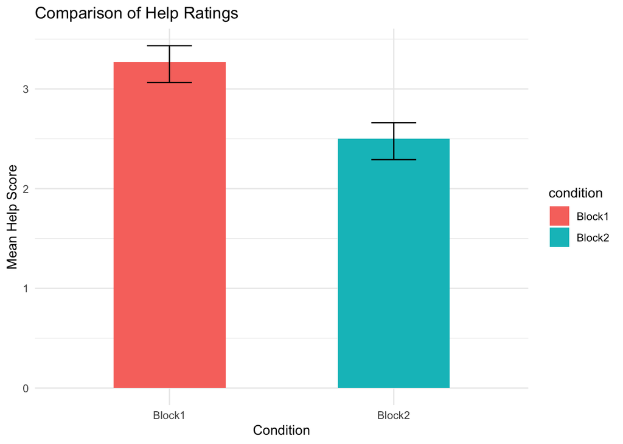

```r
help_means <- data.frame(
  condition = c("Block1", "Block2"),
  mean_help = c(mean(help1), mean(help2))
)

ggplot(help_means, aes(x = condition, y = mean_help, fill = condition)) +
  geom_bar(stat = "identity", width = 0.5) +
  geom_errorbar(aes(ymin = mean_help - sd(help1)/sqrt(length(help1)),
                    ymax = mean_help + sd(help2)/sqrt(length(help2))), width = 0.2) +
  theme_minimal() +
  labs(title = "Comparison of Help Ratings", x = "Condition", y = "Mean Help Score")
```

MOTHERLY

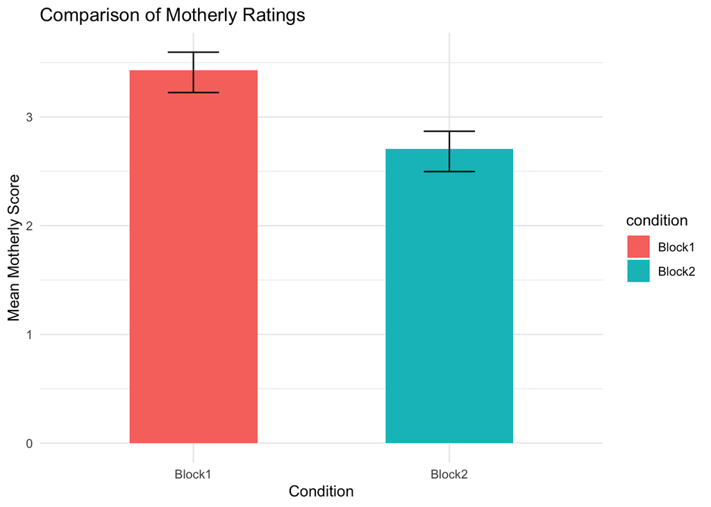

```r
motherly_means <- data.frame(
  condition = c("Block1", "Block2"),
  mean_motherly = c(mean(motherly1), mean(motherly2))
)

ggplot(motherly_means, aes(x = condition, y = mean_motherly, fill = condition)) +
  geom_bar(stat = "identity", width = 0.5) +
  geom_errorbar(aes(ymin = mean_motherly - sd(motherly1)/sqrt(length(motherly1)),
                    ymax = mean_motherly + sd(motherly2)/sqrt(length(motherly2))), width = 0.2) +
  theme_minimal() +
  labs(title = "Comparison of Motherly Ratings", x = "Condition", y = "Mean Motherly Score")
```

PROTECTIVE

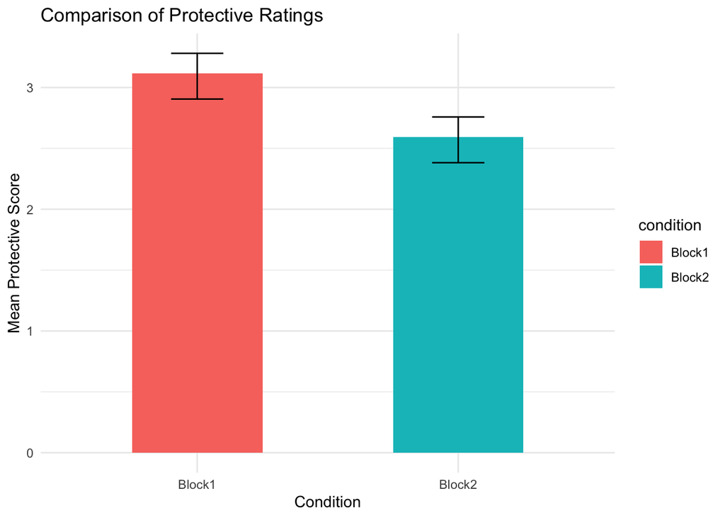

```r
protective_means <- data.frame(
  condition = c("Block1", "Block2"),
  mean_protective = c(mean(protective1), mean(protective2))
)

ggplot(protective_means, aes(x = condition, y = mean_protective, fill = condition)) +
  geom_bar(stat = "identity", width = 0.5) +
  geom_errorbar(aes(ymin = mean_protective - sd(protective1)/sqrt(length(protective1)),
                    ymax = mean_protective + sd(protective2)/sqrt(length(protective2))), width = 0.2) +
  theme_minimal() +
  labs(title = "Comparison of Protective Ratings", x = "Condition", y = "Mean Protective Score")
```